# Korrelation und lineare Modelle

Manfred Brill

Sommersemester 2021

# 1 Voraussetzungen

Dieses Dokument setzt voraus, dass Sie die grundlegenden Konzepte von R kennen.

```r
# R Markdwon
knitr::opts_chunk$set(echo = TRUE)
library(knitr)
library(kableExtra)
# Tidyverse
library(tidyverse)
library(modelr)
# Nachkommastellen in der Ausgabe
options(digits=3)
```

# 2 Daten

Als Datensatz verwenden wir den Datensatz *Luftfeuchtigkeit*. Dieser Datensatz stammt aus (Baumann, Horst 1992). Wir lesen die Werte mit der Funktion *read_csv2* aus dem Package *Tidyverse* ein.

```r
daten <- read_csv2("data/wassergehalt.csv")

kable(daten,
      align="l",
      caption="Tabelle 1: Der Datensatz Luftfeuchtigkeit (Angaben in %)",
      col.names=c("Luftfeuchtigkeit", "Wassergehalt")) %>%
      kable_styling(
        bootstrap_options = c("striped", "condensed"),
       full_width = T,
       position = "center")
```

Tabelle 1: Der Datensatz Luftfeuchtigkeit (Angaben in %)

| Luftfeuchtigkeit | Wassergehalt |
| --- | --- |
| 10 | 6 |
| 10 | 4 |
| 10 | 5 |
| 20 | 8 |
| 20 | 9 |
| 40 | 11 |
| 40 | 13 |
| 40 | 12 |
| 50 | 13 |
| 50 | 17 |
| 50 | 14 |
| 50 | 12 |
| 70 | 17 |
| 70 | 18 |
| 70 | 19 |
| 80 | 22 |
| 80 | 21 |
| 90 | 26 |
| 90 | 25 |
| 90 | 24 |

# 3 Kovarianz, Korrelationskoeffizient und Streuungsdiagramm

Bevor wir die Daten grafisch darstellen berechnen wir die Kovarianz und den Korrelationskoeffienten. Dazu verwenden wir die Funktionen *cov* und *cor*:

```r
cov(daten$Luftfeuchtigkeit, daten$Wassergehalt, method="pearson")
```

```
[1] 182
```

```r
cor(daten$Luftfeuchtigkeit, daten$Wassergehalt, method="pearson")
```

```
[1] 0.98
```

Wie schon bei den Streuungsmaßen verwendet R bei der Berechnung der Kovarianz den Faktor (n-1). Wir können dies korrigieren, wir verzichten in diesem Dokument darauf.

Der Korrelationskoeffizient hat mit 0.98 einen Wert der sehr nahe bei 1 liegt. Das bedeutet, dass mit großer Wahrscheinlichkeit ein linearer Zusammenhang mit positiver Steigung vorliegt.

Da wir vermuten, dass wir ausgehend von der Luftfeuchtigkeit auf den Wassergehalt schließen können, legen wir im Streuungsdiagramm die Luftfeuchtigkeit auf die x- und den Wassergehalt auf die y-Achse. Die Wertepaare im Streuungsdiagramm geben wir mit *geom_point* aus.

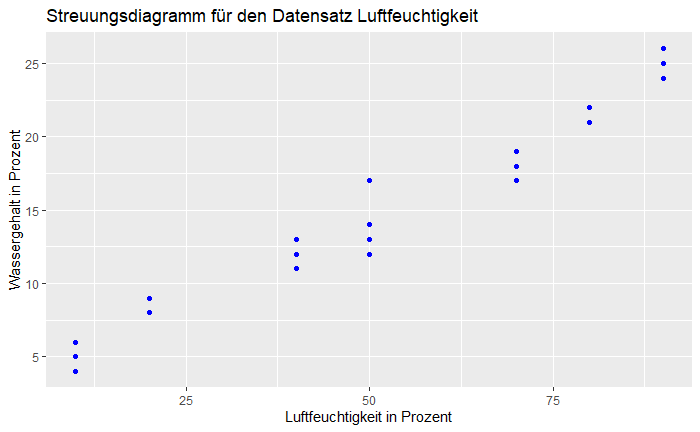

```r
ggplot(daten) +
  geom_point(mapping=aes(x=Luftfeuchtigkeit, y=Wassergehalt),
             color="blue") +
  labs(
    title="Streuungsdiagramm für den Datensatz Luftfeuchtigkeit",
    x="Luftfeuchtigkeit in Prozent",
    y="Wassergehalt in Prozent"
  )
```

# 4 Berechnung eines linearen Modells

Die Regressionsgerade, das lineare Modell für unsere Daten, berechnen wir mit Hilfe der Funktion *lm*. In der Ausgabe dieser Funktion können wir die berechnete Steigung und den Achsenabschnitt abfragen. Mit *summary()* können wir auch eine Zusammenfassung der Ergebnisse abfragen. Hier finden wir wieder die Korrelationskoeffizienten und unter *Multiple R-squared* den Werte des Bestimmungsmaßes. Ziehen wir aus diesem Wert die Wurzel erhalten wir den Korrelationskoeffizienten.

Wir berechnen jetzt das lineare Modell und geben das Ergebnis gemeinsam mit dem Streuungsdiagramm der Daten aus. Dazu speichern wir die Steigung und den Achsenabschnitt in einem Vektor *mbSim*.

```r
sim <- lm(Wassergehalt ~ Luftfeuchtigkeit, data = daten)
summary(sim)
```

```
Call:
lm(formula = Wassergehalt ~ Luftfeuchtigkeit, data = daten)

Residuals:
    Min      1Q  Median      3Q     Max
-2.4463 -1.0320 -0.0507  0.9307  2.5537

Coefficients:
                 Estimate Std. Error t value Pr(>|t|)
(Intercept)        2.6551     0.6624    4.01  0.00082 ***
Luftfeuchtigkeit   0.2358     0.0114   20.71  5.3e-14 ***
---
Signif. codes:  0 ‘***’ 0.001 ‘**’ 0.01 ‘*’ 0.05 ‘.’ 0.1 ‘ ’ 1

Residual standard error: 1.38 on 18 degrees of freedom
Multiple R-squared:  0.96,  Adjusted R-squared:  0.957
F-statistic:  429 on 1 and 18 DF,  p-value: 5.25e-14
```

```r
mbSim <- coef(sim)
```

Die Ausgabe von *summary* gibt uns die Details über das berechnete lineare Modell. In den Zeilen unterhalb von *Coefficients* finden wir die Werte für den Achsenabschnitt und Steigung. Der Achsenabschnitt, englisch *Intercept*, hat hier einen Wert von 2.6551. Die Steigung, also der Koeffizient, mit dem wir den Wert der Luftfeuchtigkeit multiplizieren, finden wir unter *Luftfeuchtigkeit*, er hat einen Wert von 0.2358. Die restlichen Angaben in diesen beiden Zeilen betrachten wir später. Wichtig sind die Wahrscheinlichkeiten, die sogenannten p-values, in der letzten Spalte. Sie sind kleiner als 0.05, deshalb finden wir auch die drei Sterne als *Significance codes*. Dies deutet darauf hin, dass das lineare Modell die Daten gub beschreibt. In der vorletzten Zeile finden wir das Bestimmtheitsmaß bei *Multiple R-squared*, hier finden wir einen Wert von 0.96, was ebenfalls auf einen hohen Erklärungswert des Modells hinweist. Das angegebene Bestimmtheitsmaß ist das Quadat des Korrelationskoeffizienten, den wir oben bereits as ungefähr 0.98 berechnet hatten.

Wir fügen dem Streuungsdiagramm die berechnete Gerade mit Hilfe der Funktion *geom_abline* hinzu. Die berechneten Werte für die Steigung und den Achsenabschnitt fügen wir der Beschriftung der Grafik hinzu.

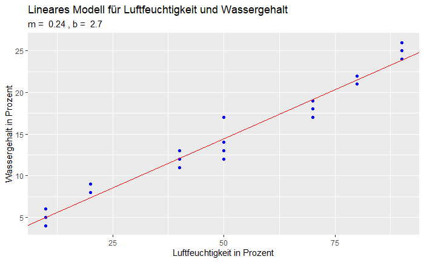

```r
ggplot(daten) +
  geom_point(mapping=aes(x=Luftfeuchtigkeit, y=Wassergehalt),
             color="blue") +
  geom_abline(intercept=mbSim[1], slope=mbSim[2], color="red") +
  labs(
    title="Lineares Modell für Luftfeuchtigkeit und Wassergehalt",
    subtitle=paste("m = ", format(mbSim[2], digits=2),
                   ", b = ", format(mbSim[1], digits=2)),
    x="Luftfeuchtigkeit in Prozent",
    y="Wassergehalt in Prozent"
  )
```

# 5 Vorhersagen

Die Hauptanwendung für ein solches lineare Modell ist es, Vorhersagen für nicht gemessene Werte der Luftfeuchtigkeit zu machen. Dafür gibt es in R die Funktion *predict*. Dazu erzeugen wir einen neuen data.frame mit den x-Werte, für die wir Vorhersagen suchen und setzen diese Werte in *predict* ein:

```r
luft <- data.frame(Luftfeuchtigkeit = c(60.0, 70.0));

predict(sim, luft)
```

```
   1    2
16.8 19.2
```

Bei 60 Prozent Luftfeuchtigkeit sagt unser Modell einen Wassergehalt von 16.8 Prozent voraus. Für 70 Prozent Luftfeuchtigkeit wird ein Wert von 19.2 Prozent vorhergesagt.

# 6 Residualplot

Wir können die Qualität unseres linearen Modells mit Hilfe eines *Residualplots* visualisieren. Dazu verwenden wir die Funktion *add_residuals* aus dem Package *modelr*.

```r
daten <- daten %>%
  add_residuals(sim)
```

In die grafische Darstellung legen wir jetzt die neu berechnete Spalte mit dem Namen *resid* und fügen eine Referenzlinie bei y=0 hinzu:

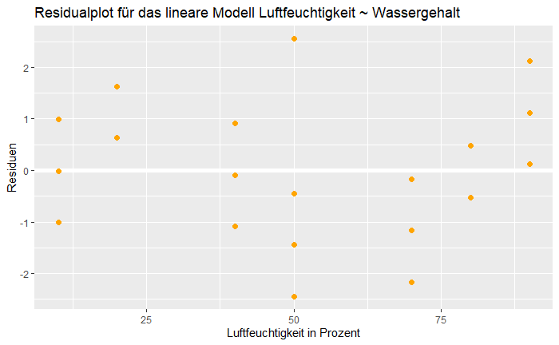

```r
ggplot(daten, aes(Luftfeuchtigkeit, resid)) +
  geom_ref_line(h=0) +
  geom_point(size=2.0, color="orange") +
  labs(
    title="Residualplot für das lineare Modell Luftfeuchtigkeit ~ Wassergehalt",
    x="Luftfeuchtigkeit in Prozent",
    y="Residuen"
  )
```

Wenn sich die dargestellten Residuen mehr oder weniger zufällig um die Referenzlinie verteilen können wir davon ausgehen, dass wir keinen systematischen Fehler im Modell haben. Sind Muster im Residualplot zu sehen sollte man nach anderen, nicht-linearen Modellen suchen.

# 7 Literaturverzeichnis

Baumann, Horst. 1992. *Lehr- Und übungsbuch Mathematik Iv*. Fachbuchverlag Leipzig.